# DataScience-Assignment3-LingyuWang

Lingyu Wang

2020/2/14

### Problem 1

Download the first `Kirb21` subject data. Use this package to read in the first subject. Calculate and report the intracranial volume: the sum of the level 1 type 1 volumes.

```r
# Download the package required to read the data
# source("https://neuroconductor.org/neurocLite.R")
# Default Install
devtools::install_github("bcaffo/MRIcloudT1volumetrics")
library(MRIcloudT1volumetrics)
library(tidyverse)
library(dplyr)

# attach the file directory
roiDir="~/Downloads/DataScience/Assignment3/data/"
filelist=dir(roiDir)

# read in the data and name it as ds_dat1
ds_dat1<-readSubject(paste(roiDir,filelist[1],sep="")) %>% subject2df()

# use filter and summarise function in the tidyverse package to do the calculaton
ds_dat1 %>% filter(type==1 & level==1) %>% summarise(sum(volume))
```

```
##   sum(volume)
## 1     1378295
```

```r
# The sum volume is 1378295
```

The intracranial volume of the type 1 and level 1 is 1,378,295.

### Problem 2

Read in the class data from here `https://github.com/bcaffo/ds4bme/blob/master/data/classInterests.txt`. Use ggplot to create bar plots of year and program.

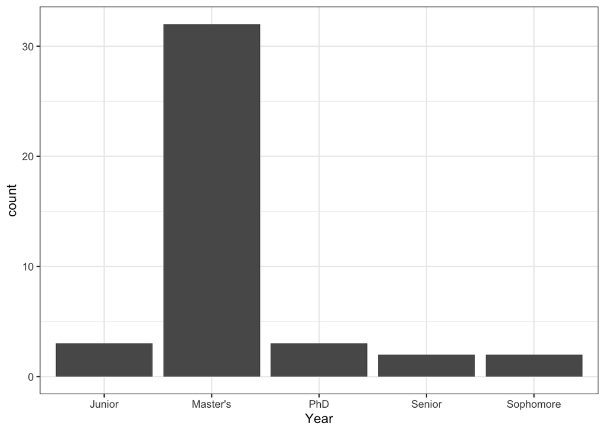

```r
library(ggplot2)
# read in the data
ds_dat2<-read.csv("https://raw.githubusercontent.com/bcaffo/ds4ph-bme/master/data/classInterests.txt",header = T,sep="")

# use ggplot to create bar plot of Year
ggplot(data = ds_dat2,aes(x=Year)) + geom_bar() +theme_bw()
```

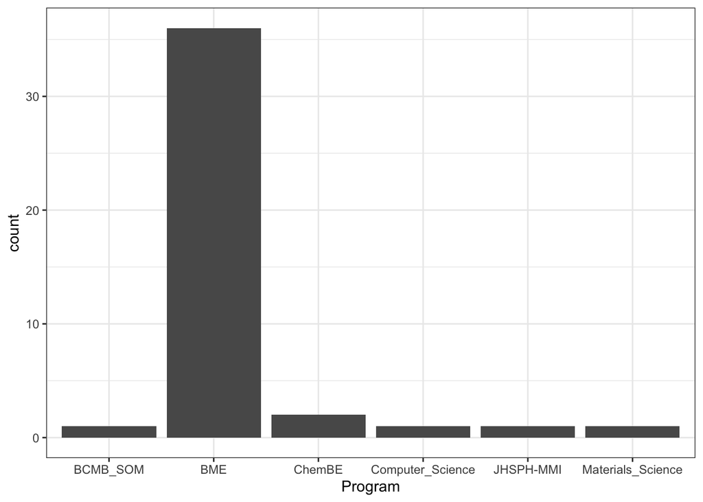

```r
# use ggplot to create bar plot of Program
ggplot(data = ds_dat2,aes(x=Program)) + geom_bar() +theme_bw()
```

### Problem 3

Create a mosaic plot of the class data for year and program.

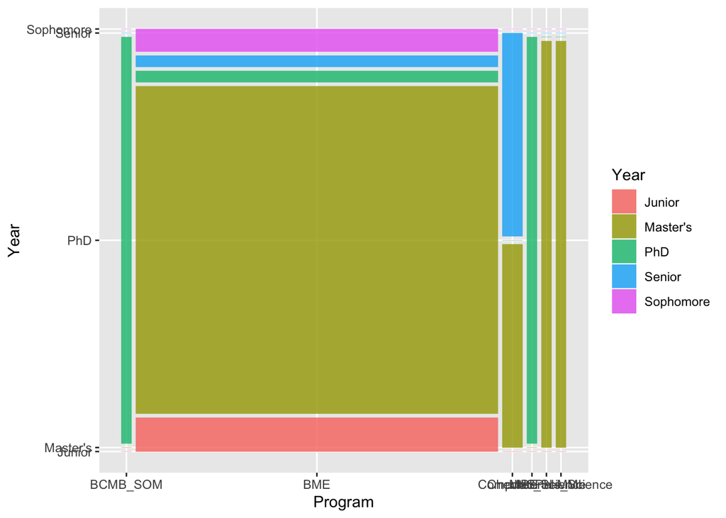

```r
devtools::install_github("haleyjeppson/ggmosaic")
library(ggmosaic)

ggplot(data=ds_dat2) + geom_mosaic(aes(x=product(Year,Program),fill=Year))
```

### Problem 4

Download the gene expression dataset from here. Information about the data can be found in the sample info here. From the gene expression data matrix, subtract the rowmean from each row and the column mean from each column so that you have a new matrix that has been demeaned across both rows and columns.

```r
# read in the data
ds_dat3<-read.csv("https://raw.githubusercontent.com/jhu-advdatasci/2018/master/data/GSE5859_exprs.csv")

# exclude the first column that doesnot contain numeric values
ds_dat3<-ds_dat3[,-1]

# calculate the row means of the matrix and store the output to a vector
row_mean<-rowMeans(ds_dat3)

# calculate the column means of the matrix and store the output to a vector
column_mean<-colMeans(ds_dat3)

# Method-1: use the "for" loop to calculate the substraction
# this method is easy to interpret but is slow on computation power
ds_dat3_method1<-ds_dat3
#for (i in 1:nrow(ds_dat3_method1)){
#  for (j in 1:ncol(ds_dat3_method1)){
#    ds_dat3_method1[i,j]<-ds_dat3_method1[i,j]-row_mean[i]-column_mean[j]
#  }
#}

# Method-2: use the base "sweep" function
# this method is quick and also easy
ds_dat3_method2<-sweep(ds_dat3,1,row_mean)
ds_dat3_method2<-sweep(ds_dat3,2,column_mean)
```

### Problem 5

Download the data from here. Create plots of healthcare spending versus time color coded by states.

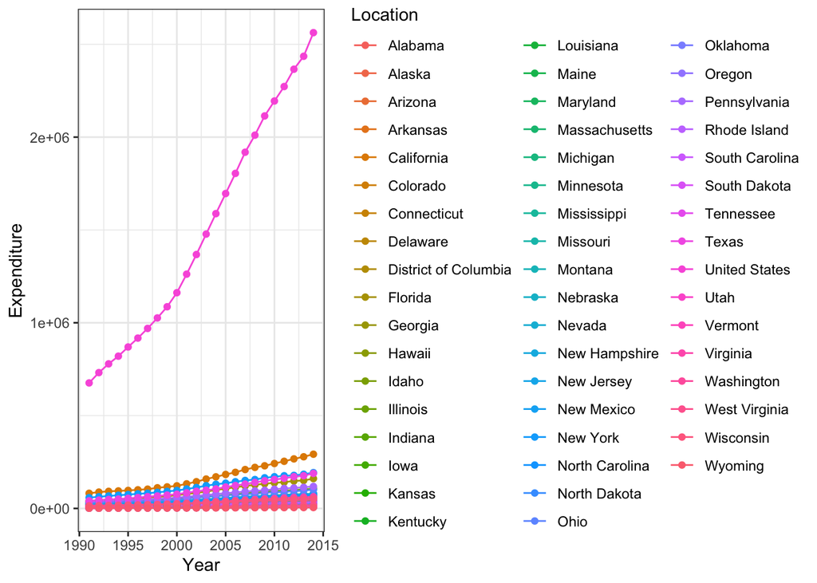

```r
# read in the data
ds_dat4<-read.csv("https://raw.githubusercontent.com/jhu-advdatasci/2018/master/data/KFF/healthcare-spending.csv",skip=2)

# drop the last few lines of notes
ds_dat4<-ds_dat4[-(53:61),]

# change the name of variables to the specific year of health expenditure
colnames(ds_dat4)<-c("Location",seq(1991,2014,1))

# change the data into "long" format with each row as one observation
library(tidyr)
ds_dat4_long<-gather(ds_dat4,Year,Expenditure,"1991":"2014")
ds_dat4_long$Year<-as.numeric(ds_dat4_long$Year)

# create the plot
ggplot(data=ds_dat4_long,aes(x=Year,y=Expenditure,col=Location)) + geom_line() +geom_point() +theme_bw()
```

### Problem 6

Refer to the previous data. Create a barplot of average health care spending by state

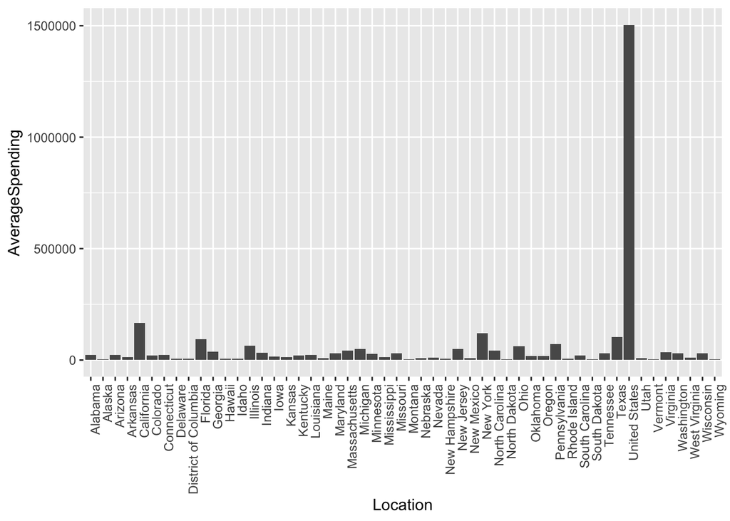

```r
# calculate the average health care spending
ds_dat4_long %>%
  group_by(Location) %>%
  summarise(AverageSpending=mean(Expenditure)) %>%
  ggplot(aes(Location,AverageSpending)) + geom_col() +
  theme(axis.text.x = element_text(angle = 90, hjust = 1))
```